# Jigsaw puzzle pieces classification

Lemikhova Liliya, Kuimov Mikhail

## Introduction

[figure not shown]

## Goal

- Solve some puzzles with the help of CV alorithms ### But...

It turned out to be not as straight forward!

## Goal

- Solve some puzzles with the help of CV alorithms
- Make preprocessing for jigsaw puzzle solving

## Problem statement

**Given:** Image of jigsaw puzzle viewed from the top. Puzzle pieces do not overlap each other.

**Goal:**

- Define 4 edges for each piece.
- Classify its shape: inner lock, outer lock or edge.

[figure not shown]

## Our Data

- Sample from $2$ puzzle packs
  - $35$ segments
  - different backgrounds
  - different rotations
  - strongly curved edged piece example

## Examples

[figure not shown]

## Examples

[figure not shown]

## Algorithm

### 1. Identify each piece

- Separate pieces from background
- Find external contours
- Choose pieces on special condition, for example area, perimeter or form

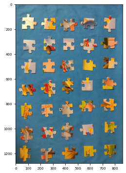

```python
img_orig = cv2.imread('dambo_blue_straight.jpg')
img_orig = img_orig[..., ::-1]
plt.figure(figsize = (8, 6))
plt.imshow(img_orig)
img = cv2.GaussianBlur(img_orig, (11, 11), 0)
```

#### Remove background

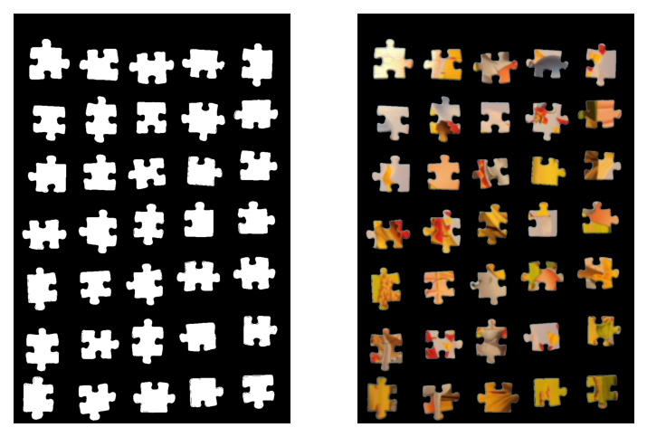

```python
HLS = cv2.cvtColor(img, cv2.COLOR_RGB2HLS)

background = np.median(HLS, axis=(0,1))
mask = np.mean(np.abs(HLS-background), axis=-1) < 30
img2 = img.copy()
img2[mask] = 0

plt.figure(dpi=150)
plt.subplot(1,2,1)
plt.axis('off')
plt.imshow(1 - mask, cmap="gray")
plt.subplot(1,2,2)
plt.axis('off')
plt.imshow(img2);
```

#### Morphology

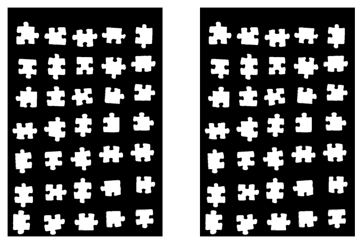

```python
img2 = img.copy()
img2[mask_int == 1] = 0


plt.figure(dpi=150)
plt.subplot(1,2,1)
plt.axis('off')
plt.imshow(1 - mask, cmap="gray")
plt.subplot(1,2,2)
plt.axis('off')
plt.imshow(1 - mask_int, cmap="gray");
```

#### Drawing contours

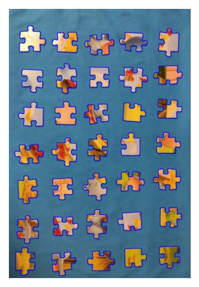

```python
contours, hierarchy = cv2.findContours(1-mask_int, cv2.RETR_EXTERNAL, cv2.CHAIN_APPROX_SIMPLE)
areas = []
for i in range(len(contours)):
    areas.append(cv2.contourArea(contours[i]))
cont_to_del = []
for i in range(len(contours)):
    if areas[i] < 0.5 * max(areas):
        cont_to_del.append(i)

contours = [contours[i] for i in range(len(contours)) if i not in cont_to_del]

img_cnt = img.copy()
cv2.drawContours(img_cnt, contours, -1, (0,0,255), 2)
plt.figure(dpi=150)
plt.axis('off')
plt.imshow(img_cnt);
```

### 2. Find 4 corners

- Harris corner detection
- Non-maximum suppression
- Selection of 4 segments, which form rectangle with biggest area

#### Corner detection

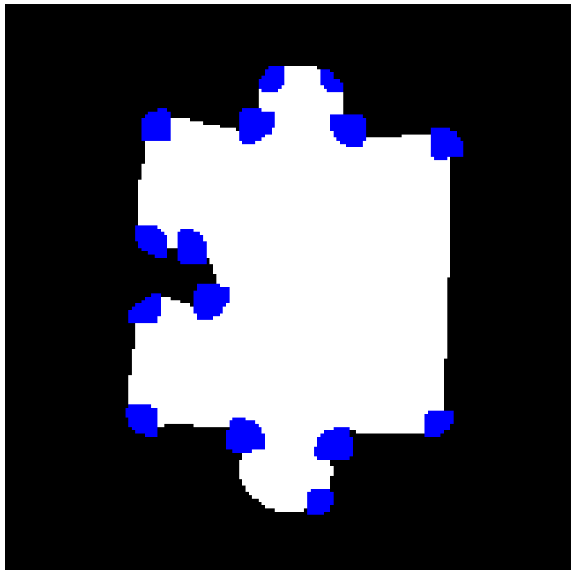

```python
gray = cv2.cvtColor(black,cv2.COLOR_BGR2GRAY)
dst = cv2.cornerHarris(gray,10,5,0.04)
dst = cv2.dilate(dst,None)
mask = dst > 0.15*dst.max()
blackk = black.copy()
blackk[mask]=[0,0,255]
plot_img(blackk)
```

#### Non maximum supression

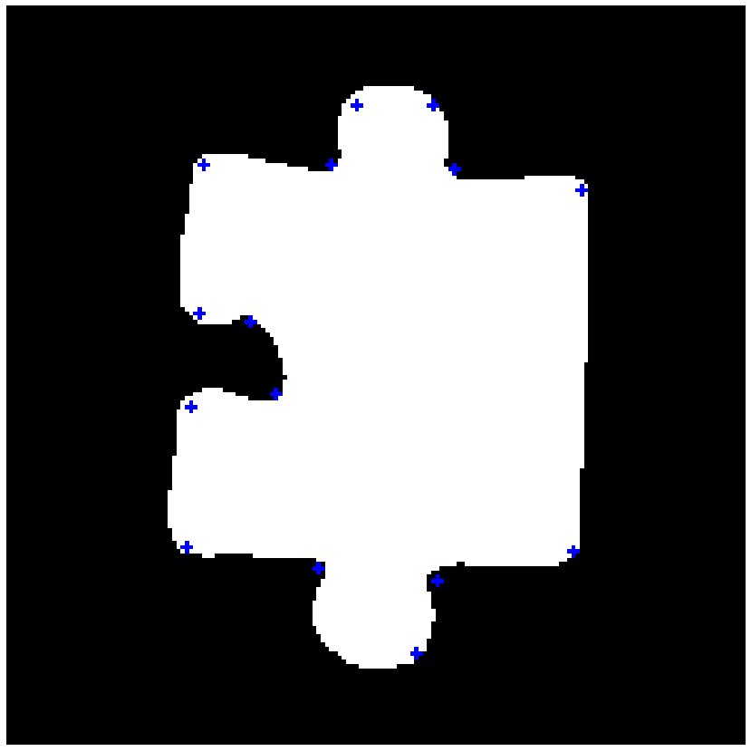

```python
filtered_points = get_local_centers(dst, 0.15*dst.max())

blackk = black.copy()
for point in filtered_points:
    blackk[point[0]][point[1]]=[0,0,255]
    blackk[point[0]-1][point[1]]=[0,0,255]
    blackk[point[0]][point[1]-1]=[0,0,255]
    blackk[point[0]+1][point[1]]=[0,0,255]
    blackk[point[0]][point[1]+1]=[0,0,255]
plot_img(blackk)
```

### Find angles

```python
# find the features to find four points, corresponding to the most rectangular frame
def find_rect_scores_2(dots):
    dots = list(dots)
    dots = np.array(dots)
    area = cv2.contourArea(dots)
    mse = 0
    da = []
    angles = compute_angles(dots)
    for i1, i2, i3 in [(0, 1, 2), (1, 2, 3), (2, 3, 0), (3, 0, 1)]:
        diff_angle = abs(angles[i1, i2] - angles[i2, i3])
        da.append(abs(diff_angle))
        mse += np.abs(diff_angle - 90) ** 2
    return [area, mse, np.mean(da)]

scores = [find_rect_scores_2(four) for j, four in enumerate(fours)]
scores_final = np.array(scores).T
scores_final = scores_final[0]*norm(0, 150).pdf(scores_final[1])
```

```python
corner_points = list(fours[np.argmax(scores_final)])
corner_points = np.array(order_points_2(corner_points))
```

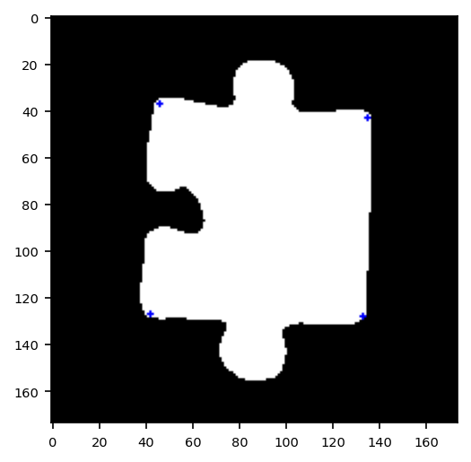

```python
blackk = black.copy()
for point in corner_points:
    blackk[point[0]][point[1]]=[0,0,255]
    blackk[point[0]-1][point[1]]=[0,0,255]
    blackk[point[0]][point[1]-1]=[0,0,255]
    blackk[point[0]+1][point[1]]=[0,0,255]
    blackk[point[0]][point[1]+1]=[0,0,255]
plt.figure(dpi=150)
plt.imshow(blackk, cmap='gray');
```

## 3. Extract 4 edges

- Center coordinates
- Line between 2 neighbour corners
- Closest points from contour to corner

#### Closest points from contour to corner

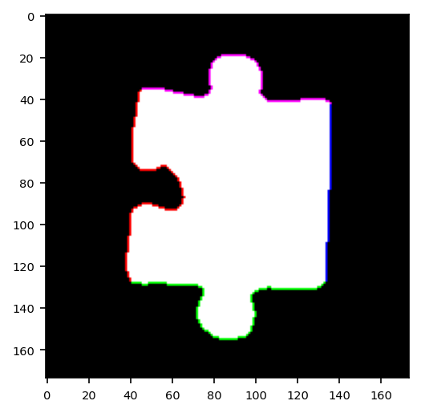

```python
blackk = black.copy()
dists = np.zeros((4, len(contours_piece[0])))
for i in range(len(contours_piece[0])):
    for j in range(4):
        dists[j, i] = dist(contours_piece[0][i][0], corner_points[j])
closest_points_index = sorted(dists.argmin(axis = 1))

colors = [(255, 0, 0), (0, 255, 0), (0, 0, 255), (255, 0, 255)]
edges = [[] for i in range(4)]
for i in range(4):
    if i < 3:
        edges[i] = contours_piece[0][closest_points_index[i]:closest_points_index[i+1]+1]
        cv2.polylines(blackk, [edges[i]], False, colors[i])
    else:
        edges[i] = np.vstack([contours_piece[0][closest_points_index[i]:], contours_piece[0][:closest_points_index[0]+1]])
        cv2.polylines(blackk, [edges[i]], False, colors[i])
plt.figure(dpi=150)
plt.imshow(blackk)

corner_points = [corner_points[i] for i in np.argsort(dists.argmin(axis = 1))]
```

# 4. Classify edges

- Compute mean coordinates of points for each edge
- Find point of an edge with max distance to a line

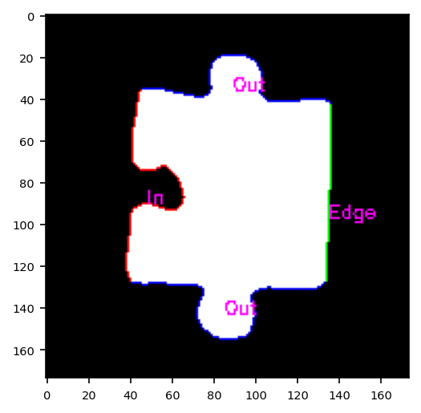

```python
blackk = black.copy()
for i in range(4):
    dists = np.zeros(len(edges[i]))
    for j in range(len(edges[i])):
        dists[j] = dist_to_line(lines[i][0], lines[i][1], edges[i][j])
    piece_center = contours_piece[0].mean(axis = 0)[0].astype(int)
    deviated_point = edges[i][dists.argmax()]
    [p1, p2] = [corner_points[i], corner_points[(i+1)%4]]

    sin_edge = np.cross(p2 - p1, deviated_point - p1)/(np.linalg.norm(p2 - p1)*np.linalg.norm(deviated_point - p1))
    sin_center = np.cross(p2 - p1, piece_center - p1)/(np.linalg.norm(p2 - p1)*np.linalg.norm(piece_center - p1))
    if dists.max() < 0.1 * dist(lines[i][0], lines[i][1]):
        color = (0, 255, 0)
        label = 'Edge'
    elif sin_edge * sin_center < 0:
        color = (0, 0, 255)
        label = 'Out'
    elif sin_edge * sin_center > 0:
        color = (255, 0, 0)
        label = 'In'
    cv2.polylines(blackk, [edges[i]], False, color)
    cv2.putText(blackk, label, (int(edges[i].mean(axis = 0)[0][0]),int(edges[i].mean(axis = 0)[0][1]) + 5),
                cv2.FONT_HERSHEY_SIMPLEX,0.3, (255, 0, 255), 1)
plt.figure(dpi=150)
plt.imshow(blackk);
```

### Metric

1. Count $f_1 ~ score$ for every piece: `score_i`
2. If all incorrect, than `score_i -= 1`
3. Transform values to $[0,1]$
4. Count mean of all `score_i`

### Classification of all puzzle pieces

```python
img_classified = img_orig.copy()
scores = []
for k in tqdm(range(len(contours))):
    gold_l = np.array(gold_lb[gold_lb["puzzle indices"] == k]['labels'])
    img_cp = img_orig.copy()
    black = np.zeros_like(img)
    cv2.drawContours(black, [contours[k]], 0, (255,255,255), 1)
    cv2.fillPoly(black, pts =[contours[k]], color=(255,255,255))
    black, slices = create_box(black, contours[k])
    img_cp, slices = create_box(img_cp, contours[k])
    new_segment, score = segment_classifier(black, img_cp, gold_labels=gold_l)
    scores.append(score)
    img_classified[slices[0][0] : slices[0][1], slices[1][0] : slices[1][1]] = new_segment
```

[figure not shown]

```python
plot_img(img_classified)
```

```python
if k < 34:
    scores = scores + [-1]*(34 - k)
score = ((np.array(scores) + 1) / 2).mean()
print('The score is: ', score)
```

```
The score is:  1.0
```

# Results

[figure not shown]

# Results

[figure not shown]

## Results

[figure not shown]

## Rotation of segments

[figure not shown]

## Betas

[figure not shown]

## Conclusion

- Algorith works fine
- It was a great journey!